# BOO 2025 - Example Analysis

# 3 Defining DEGs

## 3.1 Thresholds

There are many ways to define a differentially expressed gene based either on the log2 fold change (log2FC, which reflects the effect size), the adjusted p-value (which reflects the statistical significance after correcting for multiple testing), or a combination of both. For example, some studies may define a gene as differentially expressed if it has an adjusted p-value below 0.05, indicating high statistical confidence, while others may require an absolute log2FC above log2(1.2) (i.e., a twenty percent change) to ensure the change is also biologically meaningful. Combining both criteria helps balance sensitivity and specificity, reducing the chance of identifying genes that are statistically but not biologically relevant, or vice versa.

**Exercise 14: Create two new variables `dir` and `sig` that describe each gene’s significance (T/F) and direction of effect (up/down):**

**Hint**

Don’t forget to do it for the high and low toxicity compounds.

```r
res_high <- res_high %>%
  mutate(
    dir = ifelse(log2FoldChange < 0, "Down", "Up"), #If log2FoldChange is less than 0, the dir column for that gene will be assigned the string "Down" (indicating downregulation).

    sig = ifelse(padj <= 0.05 & abs(log2FoldChange) > log2(1.2), TRUE, FALSE)
  ) #The adjusted p-value. / This means the gene's expression must have changed by at least a 1.2-fold increase (e.g., from 10 to 12) or a 1.2-fold decrease (e.g., from 10 to 10/1.2 ≈ 8.33) to be considered biologically meaningful enough by this threshold.

table(res_high$sig, res_high$dir, useNA="always")
```

```
##
##          Down    Up  <NA>
##   FALSE 68668 65043     0
##   TRUE     62   133     0
##   <NA>    118   191 23516
```

```r
res_low <- res_low %>%
  mutate(
    dir = ifelse(log2FoldChange < 0, "Down", "Up"),
    sig = ifelse(padj <= 0.05 & abs(log2FoldChange) > log2(1.2), TRUE, FALSE)
  )

table(res_low$sig, res_low$dir, useNA="always")
```

```
##
##          Down    Up  <NA>
##   FALSE 63095 62510     0
##   TRUE   4781  4457     0
##   <NA>   1902  2571 18415
```

## 3.2 Save

It is important to save output of analyses locally, especially when they can be quite lengthy to rerun. This will save you considerable time later in the project.

**Exercise 15: Save the results using the path variables you created at the start of the script:**

```r
write.csv(res_low,"output/low_store.csv")
write.csv(res_high,"output/high_store.csv")

write_csv(res_low,"output/low_store.csv")
write_csv(res_high,"output/high_store.csv")
```

# 4 Plots

## 4.1 Dose-response plots

One of the plots that is useful to make following DEG analysis is visualization of any dose response effects. In order to ensure that all data point are plotted correctly, it is helpful to create a base data frame for all the direction, concentration combinations.

**Exercise 16: Create a data frame `plot_df` with all compound, concentration, and direction combinations:**

**Hint**

It may be helpful to `rbind()` your high and low toxicity compound results together for visualizations.

```r
res <- rbind(res_high, res_low)

plot_df <- res %>%
  filter(!is.na(dir)) %>%
  select(mean_ID, dir) %>%
  distinct()

plot_df
```

| mean_ID | dir |
| --- | --- |
| CS1106_1_P1 | Up |
| CS1106_1_P1 | Down |
| CS1106_2_P1 | Down |
| CS1106_2_P1 | Up |
| CS1106_3_P1 | Down |
| CS1106_3_P1 | Up |
| CS1106_4_P1 | Down |
| CS1106_4_P1 | Up |
| CS1106_5_P1 | Down |
| CS1106_5_P1 | Up |

[output cut: 18 more lines]

[output not shown]

Using `mean_ID` and `separate()`, you can extract information about the compound and concentration of each experimental group.

**Exercise 17: Create a data frame containing the number of DEGs, concentration, and compound, for each experimental condition and direction:**

**Hint**

Don’t forget to set the number of DEGs to 0, where appropriate.

```r
plot_df <- res %>%
  filter(sig == TRUE & !is.na(dir)) %>%
  group_by(mean_ID, dir) %>%
  summarize(n = n(), .groups = "drop") %>%
  right_join(y = plot_df, by = c("mean_ID", "dir")) %>%
  mutate(n = ifelse(is.na(n), 0, n)) %>%
  separate(mean_ID, sep="_", into=c("Compound", "Conc_ID", NA), remove=F)

plot_df
```

| mean_ID | Compound | Conc_ID | dir | n |
| --- | --- | --- | --- | --- |
| CS1106_1_P1 | CS1106 | 1 | Down | 46 |
| CS1106_1_P1 | CS1106 | 1 | Up | 25 |
| CS1106_2_P1 | CS1106 | 2 | Down | 14 |
| CS1106_2_P1 | CS1106 | 2 | Up | 88 |
| CS1106_4_P1 | CS1106 | 4 | Up | 15 |
| CS1106_6_P1 | CS1106 | 6 | Down | 1 |
| CS1106_6_P1 | CS1106 | 6 | Up | 4 |
| CS1106_7_P1 | CS1106 | 7 | Down | 1 |
| CS1106_7_P1 | CS1106 | 7 | Up | 1 |
| CS1133_1_P6 | CS1133 | 1 | Down | 163 |

[output cut: 18 more lines]

[output not shown]

**Exercise 18: Plot the number of DEGs across concentrations for the two compounds. Do you see a dose-response?**

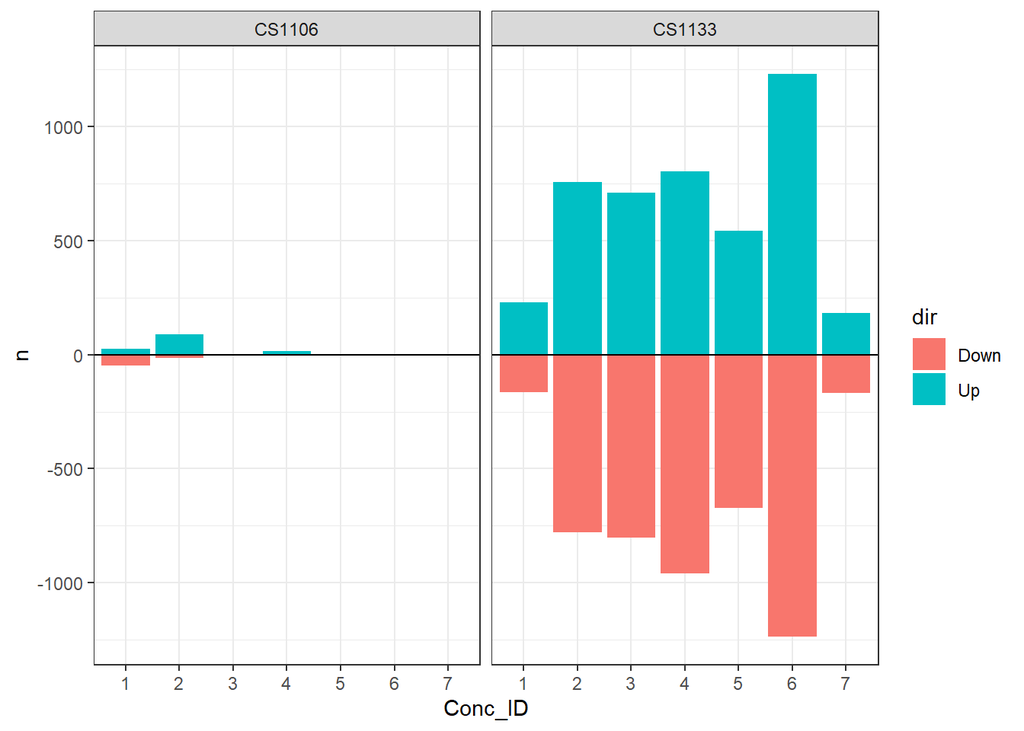

```r
plot_df %>%
  mutate(n = ifelse(dir == "Down", -n, n)) %>%
  ggplot(aes(x=Conc_ID, y=n, fill=dir)) +
  geom_col() +
  geom_hline(aes(yintercept=0)) +
  theme_bw() +
  facet_wrap(~Compound, scales="free_x")
```

```r
#CS116 is High TOX
```

## 4.2 Volcano plots

A volcano plot is useful to visualize effect sizes and significance of each gene in one plot, by plotting log2 fold changes (x-axis) against -log10 p-values (y-axis).

**Exercise 19: Create volcano plots for each of the compounds:**

**Hint**

If you want to plot all concentrations, it may be sensible to create distinct plots for the two compounds. However, you could also plot only the top concentration volcano plot, if the dose response is suggestive that this would be more informative.

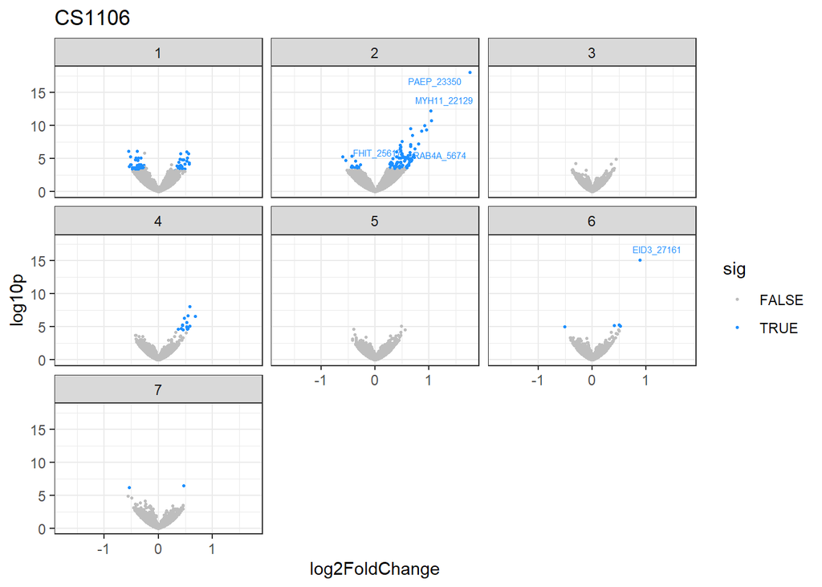

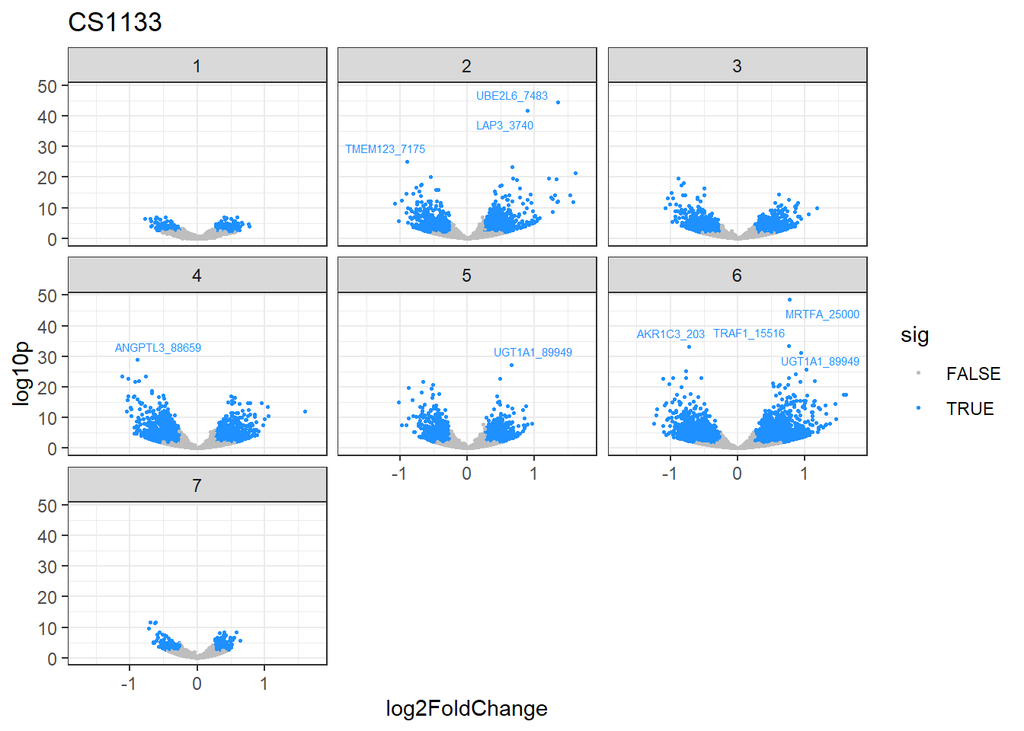

```r
for(i in unique(metaData$compound_ID)[1:2]) {
  print(res %>%
          separate(mean_ID, sep="_", into=c("Compound", "Conc_ID", NA), remove=F) %>%
          filter(!is.na(sig) & Compound == i) %>%
          mutate(log10p = -log10(pvalue)) %>%
          ggplot(aes(x = log2FoldChange, y = log10p)) +
          geom_point(aes(color=sig), size=0.5) +
          geom_text_repel(aes(label = ifelse(padj < 1E-4, gene_symbol, NA)),
                    color="dodgerblue", size=2) +
          xlim(-max(abs(res$log2FoldChange), na.rm=T), max(abs(res$log2FoldChange), na.rm=T)) +
          scale_color_manual(values = c("grey", "dodgerblue")) +
          theme_bw() +
          ggtitle(i) +
          facet_wrap(~Conc_ID))
}
```

## 4.3 MA plots

**Exercise 20: Create MA plots for the two compounds. Outline your findings:**

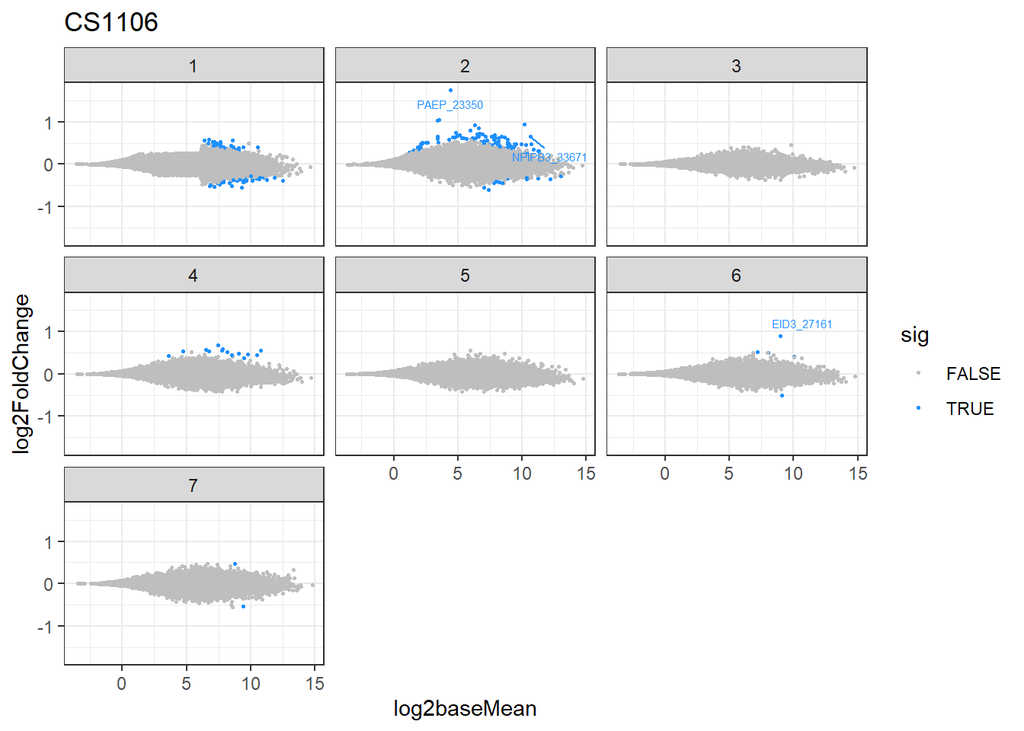

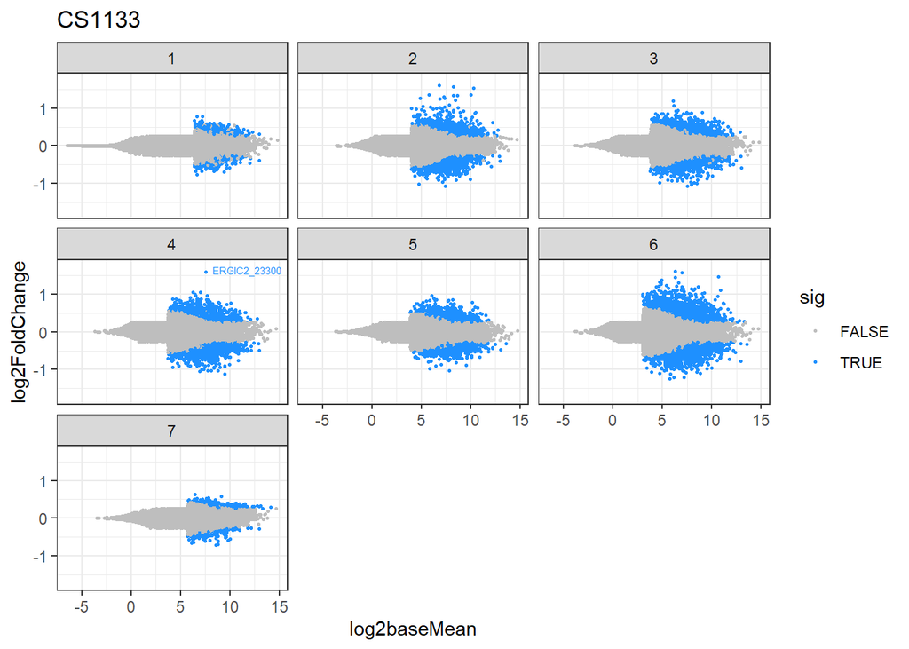

```r
for(i in unique(metaData$compound_ID)[1:2]) {
  print(res %>%
          separate(mean_ID, sep="_", into=c("Compound", "Conc_ID", NA), remove=F) %>%
          filter(!is.na(sig) & Compound == i) %>%
          mutate(log2baseMean = log2(baseMean)) %>%
          ggplot(aes(x = log2baseMean, y = log2FoldChange)) +
          geom_point(aes(color=sig), size=0.5) +
          geom_text_repel(aes(label = ifelse(padj < 1E-4, gene_symbol, NA)),
                    color="dodgerblue", size=2) +
          ylim(-max(abs(res$log2FoldChange), na.rm=T), max(abs(res$log2FoldChange), na.rm=T)) +
          scale_color_manual(values = c("grey", "dodgerblue")) +
          theme_bw() +
          ggtitle(i) +
          facet_wrap(~Conc_ID))
}
```